# Homework_3

Ziad Al Bkhetan

October 22, 2015

# Data Loading

```r
adult_data = read.table("http://archive.ics.uci.edu/ml/machine-learning-databases/adult/adult.data",
                  sep=",",header=F,col.names=c("age", "type_employer", "fnlwgt", "education",
                                               "education_num","marital", "occupation", "relationship", "race","sex",
                                               "capital_gain", "capital_loss", "hr_per_week","country", "income"),
                  fill=FALSE,strip.white=T)
head(adult_data)
```

```
##   age    type_employer fnlwgt education education_num            marital
## 1  39        State-gov  77516 Bachelors            13      Never-married
## 2  50 Self-emp-not-inc  83311 Bachelors            13 Married-civ-spouse
## 3  38          Private 215646   HS-grad             9           Divorced
## 4  53          Private 234721      11th             7 Married-civ-spouse
## 5  28          Private 338409 Bachelors            13 Married-civ-spouse
## 6  37          Private 284582   Masters            14 Married-civ-spouse
##          occupation  relationship  race    sex capital_gain capital_loss
## 1      Adm-clerical Not-in-family White   Male         2174            0
## 2   Exec-managerial       Husband White   Male            0            0
## 3 Handlers-cleaners Not-in-family White   Male            0            0
## 4 Handlers-cleaners       Husband Black   Male            0            0
## 5    Prof-specialty          Wife Black Female            0            0
## 6   Exec-managerial          Wife White Female            0            0
##   hr_per_week       country income
## 1          40 United-States  <=50K
## 2          13 United-States  <=50K
## 3          40 United-States  <=50K
## 4          40 United-States  <=50K
## 5          40          Cuba  <=50K
## 6          40 United-States  <=50K
```

# Data Partitioning

in this phase we will divide the dataset into two different sets the first one for classifier training while the second is for the classifier testing.  
* partion percentage is 75:25  
* target attribute to maintain good distribution “income”

```r
library(lattice)
library(ggplot2)
library(caret)
indxTrainSet <- createDataPartition(y = adult_data$income, p=0.75)
str(indxTrainSet)
```

```
## List of 1
##  $ Resample1: int [1:24421] 1 3 4 6 7 8 9 10 11 12 ...
```

```r
adultDataTrain <- adult_data[indxTrainSet$Resample1,]
adultDataTest <- adult_data[-indxTrainSet$Resample1,]
```

# Random Forests Tree Training

```r
library (randomForest)
rfTree <- randomForest(income ~ . ,na.action = na.omit, data=adultDataTrain, importance=TRUE)
rfTree
```

```
##
## Call:
##  randomForest(formula = income ~ ., data = adultDataTrain, importance = TRUE,      na.action = na.omit)
##                Type of random forest: classification
##                      Number of trees: 500
## No. of variables tried at each split: 3
##
##         OOB estimate of  error rate: 17.63%
## Confusion matrix:
##       <=50K >50K class.error
## <=50K 18491   49 0.002642934
## >50K   4257 1624 0.723856487
```

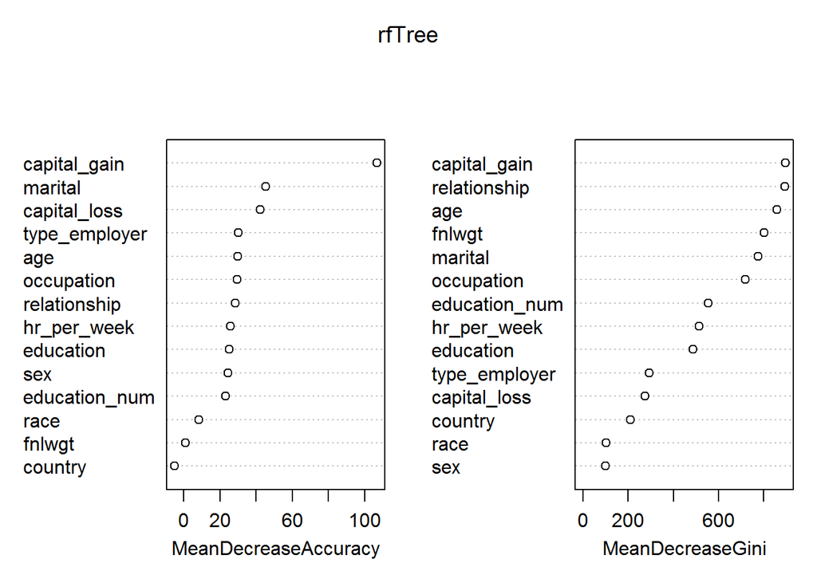

```r
varImpPlot(rfTree)
```

I will use four variables the first three important variable and fnlwgt variable “random selection” to build the final classifier

```r
rfTree <- randomForest(income ~ capital_gain+capital_loss+marital+fnlwgt ,na.action = na.omit, data=adultDataTrain, importance=TRUE)
rfTree
```

```
##
## Call:
##  randomForest(formula = income ~ capital_gain + capital_loss +      marital + fnlwgt, data = adultDataTrain, importance = TRUE,      na.action = na.omit)
##                Type of random forest: classification
##                      Number of trees: 500
## No. of variables tried at each split: 2
##
##         OOB estimate of  error rate: 17.05%
## Confusion matrix:
##       <=50K >50K class.error
## <=50K 18460   80 0.004314995
## >50K   4083 1798 0.694269682
```

# Random forest Test

```r
rfTab <-table(predicted = predict(rfTree, newdata=adultDataTest, type = "class") , real= adultDataTest$income)
rfTab
```

```
##          real
## predicted <=50K >50K
##     <=50K  6145 1351
##     >50K     35  609
```

# Results Random Forests Tree:

```r
mesTab <- matrix(c("TP", "FN", "FP", "TN"), ncol=2, nrow = 2, byrow = TRUE)
colnames(mesTab) <- c("+", "-")
rownames(mesTab) <- c("+", "-")
mesTab
```

```
##   +    -
## + "TP" "FN"
## - "FP" "TN"
```

Accurcy : the percentage of the correct prediction . (TP + TN) / (TP + TN + FP + FN)

```r
sum(diag(rfTab)) / sum(rfTab)
```

```
## [1] 0.8297297
```

Precision : The percentage of positive predictions that are correct (Positive = <=50k, negative = >50k). TP / (TP + FP)

```r
rfTab[[1]] / (rfTab[[1]] + rfTab[[2]])
```

```
## [1] 0.9943366
```

Sensitivity : The percentage of positive labeled instances that were predicted as positive. TP / (TP + FN)

```r
rfTab[[1]] / (rfTab[[1]] + rfTab[[3]])
```

```
## [1] 0.8197705
```

Specificity : The percentage of negative labeled instances that were predicted as negative. TN / (TN + FP)

```r
rfTab[[4]] / (rfTab[[4]] + rfTab[[2]])
```

```
## [1] 0.9456522
```

# Desicion Tree Training

I will use the same model as in the random forest tree to compare these classifiers based on the same mode

```r
library(rpart)
dtree <- rpart(income ~ capital_gain+capital_loss+marital+fnlwgt, data = adultDataTrain, parms=list(split = "gini"), method="class")
dtree
```

```
## n= 24421
##
## node), split, n, loss, yval, (yprob)
##       * denotes terminal node
##
##  1) root 24421 5881 <=50K (0.75918267 0.24081733)
##    2) marital=Divorced,Married-spouse-absent,Never-married,Separated,Widowed 13176  829 <=50K (0.93708257 0.06291743)
##      4) capital_gain< 7139.5 12948  609 <=50K (0.95296571 0.04703429) *
##      5) capital_gain>=7139.5 228    8 >50K (0.03508772 0.96491228) *
##    3) marital=Married-AF-spouse,Married-civ-spouse 11245 5052 <=50K (0.55073366 0.44926634)
##      6) capital_gain< 5095.5 10340 4159 <=50K (0.59777563 0.40222437)
##       12) capital_loss< 1782.5 9753 3660 <=50K (0.62473085 0.37526915) *
##       13) capital_loss>=1782.5 587   88 >50K (0.14991482 0.85008518) *
##      7) capital_gain>=5095.5 905   12 >50K (0.01325967 0.98674033) *
```

# Decision Tree Test

```r
dtab <- table(predicted = predict(dtree, newdata=adultDataTest, type = "class") , real= adultDataTest$income)

dtab
```

```
##          real
## predicted <=50K >50K
##     <=50K  6147 1425
##     >50K     33  535
```

# Results Decision Tree:

```r
mesTab <- matrix(c("TP", "FN", "FP", "TN"), ncol=2, nrow = 2, byrow = TRUE)
colnames(mesTab) <- c("+", "-")
rownames(mesTab) <- c("+", "-")
mesTab
```

```
##   +    -
## + "TP" "FN"
## - "FP" "TN"
```

Accurcy : the percentage of the correct prediction . (TP + TN) / (TP + TN + FP + FN)

```r
sum(diag(dtab)) / sum(dtab)
```

```
## [1] 0.8208845
```

Precision : The percentage of positive predictions that are correct (Positive = <=50k, negative = >50k). TP / (TP + FP)

```r
dtab[[1]] / (dtab[[1]] + dtab[[2]])
```

```
## [1] 0.9946602
```

Sensitivity : The percentage of positive labeled instances that were predicted as positive. TP / (TP + FN)

```r
dtab[[1]] / (dtab[[1]] + dtab[[3]])
```

```
## [1] 0.8118067
```

Specificity : The percentage of negative labeled instances that were predicted as negative. TN / (TN + FP)

```r
dtab[[4]] / (dtab[[4]] + dtab[[2]])
```

```
## [1] 0.9419014
```

# Remarks

I have noticed that both classifiers have the same accurecy approximatly, but it is related to the dataset it self, and usually the random forests classifier gives better accurecy